# **Introduction to Markdown**

Maintainer: Zhaohu(Jonathan) Fan contact him (fanzh@ucmail.uc.edu)

Note: This lab note is still WIP, let us know if you encounter bugs or issues.

## 1.1 What is Markdown?

## 1.2 Differences between Colab Markdown and other Markdown dialects

## 1.3 Markdown Syntax: Simplest way of writing

## 1.4 How to communicate with Python codes?

#### *Colab Notebook [Open in Colab](https://colab.research.google.com/drive/1jZregySxiTFaZw6qcBj-5VZU5X7PvbsZ?usp=sharing)*

#### *Useful information about [Introduction to RMarkdown](https://yanyudm.github.io/Data-Mining-R/lecture/1.D_IntroMarkdown.html)*

# 1.1 What is Markdown?

Colab has two types of cells: **text** and **code**. Text cells are formatted using a simple markup language called Markdown.

To see the Markdown source, double-click a text cell, showing both the Markdown source and the rendered version. Above the Markdown source there is a toolbar to assist editing.

### **Text cells**

This is a **text cell**. You can **double-click** to edit this cell. Text cells use markdown syntax. To learn more, see our markdown guide.

### **Code cells**

Below is a **code cell**. Once the toolbar button indicates CONNECTED, click in the cell to select it and execute the contents in the following ways:

- Click the **Play icon** in the left gutter of the cell;
- Type **Cmd/Ctrl+Enter** to run the cell in place;
- Type **Shift+Enter** to run the cell and move focus to the next cell (adding one if none exists); or
- Type **Alt+Enter** to run the cell and insert a new code cell immediately below it.

**Working with python**

Colab is built on top of [Jupyter Notebook](https://jupyter.org/). Below are some examples of convenience functions provided.

```python
a = 10
a
```

```
10
```

## 1.2 **Differences between Colab Markdown and other Markdown dialects**

Colab uses [marked.js](https://github.com/chjj/marked) and so is similar but not quite identical to the Markdown used by Jupyter and Github.

Colab supports (MathJax) $\LaTeX$ equations like Jupyter, but does not allow HTML tags in the Markdown. Just place the statement within a pair of **\$** signs. For example

Equations:

```
markdown
$y=x^2$

$e^{i\pi} + 1 = 0$

$e^x=\sum_{i=0}^\infty \frac{1}{i!}x^i$

$\frac{n!}{k!(n-k)!} = {n \choose k}$

$A_{m,n} =
 \begin{pmatrix}
  a_{1,1} & a_{1,2} & \cdots & a_{1,n} \\
  a_{2,1} & a_{2,2} & \cdots & a_{2,n} \\
  \vdots  & \vdots  & \ddots & \vdots  \\
  a_{m,1} & a_{m,2} & \cdots & a_{m,n}
 \end{pmatrix}$
```

$y=x^2$

$e^{i\pi} + 1 = 0$

$e^x=\sum_{i=0}^\infty \frac{1}{i!}x^i$

$\frac{n!}{k!(n-k)!} = {n \choose k}$

$A_{m,n} = \begin{pmatrix} a_{1,1} & a_{1,2} & \cdots & a_{1,n} \\ a_{2,1} & a_{2,2} & \cdots & a_{2,n} \\ \vdots & \vdots & \ddots & \vdots \\ a_{m,1} & a_{m,2} & \cdots & a_{m,n} \end{pmatrix}$

## 1.3 **Markdown Syntax: Simplest way of writing**

| Markdown | Preview |
| --- | --- |
| `**bold text**` | **bold text** |
| `*italicized text*` or `_italicized text_` | *italicized text* |
| `` `Monospace` `` | `Monospace` |
| `~~strikethrough~~` | strikethrough |
| `[A link](https://www.google.com)` | [A link](https://www.google.com) |
| `![An image](https://www.google.com/images/rss.png)` |  |

Headings are rendered as titles.

```
markdown
# Section 1
# Section 2
## Sub-section under Section 2
### Sub-section under the sub-section under Section 2
# Section 3
```

The table of contents, available on the left side of Colab, is populated using at most one section title from each text cell.

```
markdown
>One level of indentation
```

> One level of indentation

```
markdown
>>Two levels of indentation
```

> > Two levels of indentation

Ordered lists:

```
markdown
1. One
1. Two
1. Three
```

1. One
2. Two
3. Three

Unordered lists:

```
markdown
* One
* Two
* Three
```

- One
- Two
- Three

Tables:

```
markdown
First column name  | Second column name
-------------------|------------------
Row 1, Col 1       | Row 1, Col 2
Row 2, Col 1       | Row 2, Col 2
```

| First column name | Second column name |
| --- | --- |
| Row 1, Col 1 | Row 1, Col 2 |
| Row 2, Col 1 | Row 2, Col 2 |

**Magics**

Colab shares the notion of magics from Jupyter. There are shorthand annotations that change how a cell's text is executed. To learn more, see [Jupyter's magics page](http://nbviewer.jupyter.org/github/ipython/ipython/blob/1.x/examples/notebooks/Cell%20Magics.ipynb).

```python
%%html
<marquee style='width: 30%; color: blue;'><b>Welcome to BANA 7046!</b></marquee>
```

**Welcome to BANA 7046!**

## 1.4 How to communicate with Python codes?

**a. Size**

For Python use .shape

```python
#Python - size
import sklearn as sklearn
import pandas as pd
from sklearn import datasets
data = datasets.load_iris()
# Convert to Pandas dataframe
iris = pd.DataFrame(data.data, columns=data.feature_names)
iris.shape
```

```
(150, 4)
```

**b.Histogram**

Histogram for Sepal Length

For Python use .hist

```python
import numpy as np
import pandas as pd
import matplotlib.pyplot as plt
```

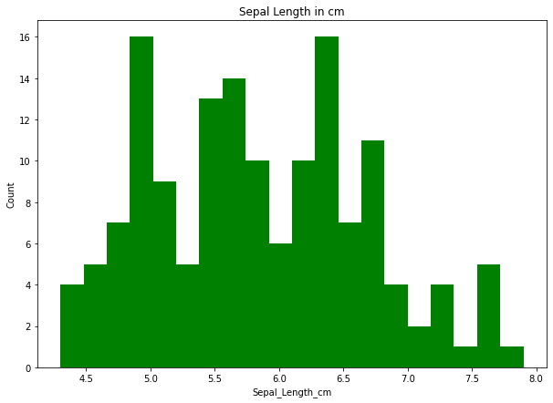

```python
plt.figure(figsize = (10, 7))
x = iris['sepal length (cm)']
plt.hist(x, bins = 20, color = "green")
plt.title("Sepal Length in cm")
plt.xlabel("Sepal_Length_cm")
plt.ylabel("Count")
```

**c.Box Plot for Iris Data**

For Python use .boxplot

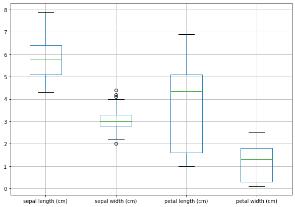

```python
plt.figure(figsize = (10, 7))
iris.boxplot()
```

```python
%%shell
jupyter nbconvert --to html ///content/1_D_Introduction_to_Markdown.ipynb
```

```
[NbConvertApp] Converting notebook ///content/1_D_Introduction_to_Markdown.ipynb to html
[NbConvertApp] Writing 328230 bytes to ///content/1_D_Introduction_to_Markdown.html
```